# Analisis Clustering Keamanan Pangan Global

Analisis Data Ketahanan Pangan

2025-10-28

# 1 Pendahuluan

Dokumen ini menyajikan analisis komprehensif hasil clustering keamanan pangan global berdasarkan berbagai indikator seperti food supply, import ratio, malnutrition rate, protein supply, dan stability index. Analisis ini menggunakan metode clustering untuk mengidentifikasi pola keamanan pangan di berbagai negara di dunia.

## 1.1 Tujuan Analisis

1. Mengidentifikasi kelompok negara berdasarkan tingkat keamanan pangan
2. Memahami karakteristik setiap cluster
3. Mengevaluasi posisi Indonesia dalam konteks global
4. Memberikan insight untuk kebijakan ketahanan pangan

```r
# Load required libraries - urutan penting untuk menghindari konflik
library(ggplot2)
library(knitr)
library(gridExtra)
library(scales)
library(tidyr)
library(reshape2)
library(ggrepel)
library(dplyr)  # Load dplyr terakhir
```

```r
# Load data hasil clustering
clustered_data <- read.csv("D:/Windows/PENS/Analitik Data Terapan/Tugas/Tugas 7 (LDA Data)/cluster-data-2.csv",
                           header = TRUE, stringsAsFactors = FALSE)

# Pastikan kolom Cluster dan Cluster_Label adalah factor
clustered_data$Cluster <- factor(clustered_data$Cluster,
                                 levels = paste0("Cluster ", 1:5))
clustered_data$Cluster_Label <- factor(clustered_data$Cluster_Label,
                                       levels = c("Generally food secure",
                                                 "Chronically food insecure",
                                                 "Acute food and livelihood crisis",
                                                 "Humanitarian emergency",
                                                 "Famine / humanitarian catastrophe"))

# Warna untuk setiap cluster (gradasi dari hijau ke merah)
cluster_colors <- c("#2E7D32", "#66BB6A", "#FFA726", "#EF5350", "#B71C1C")
names(cluster_colors) <- paste0("Cluster ", 1:5)

# Bentuk untuk setiap cluster
cluster_shapes <- c(16, 17, 15, 18, 8)  # circle, triangle, square, diamond, asterisk
names(cluster_shapes) <- paste0("Cluster ", 1:5)
```

# 2 Executive Summary

```r
total_countries <- nrow(clustered_data)
indonesia_cluster <- clustered_data %>%
  filter(grepl("Indonesia", Area, ignore.case = TRUE)) %>%
  pull(Cluster) %>%
  as.character()

indonesia_label <- clustered_data %>%
  filter(grepl("Indonesia", Area, ignore.case = TRUE)) %>%
  pull(Cluster_Label) %>%
  as.character()

cat("## Ringkasan Eksekutif\n\n")
```

```
## ## Ringkasan Eksekutif
```

```r
cat("- **Total negara yang dianalisis:** ", total_countries, " negara\n")
```

```
## - **Total negara yang dianalisis:**  167  negara
```

```r
cat("- **Jumlah cluster:** 5 cluster dengan tingkat keamanan pangan berbeda\n")
```

```
## - **Jumlah cluster:** 5 cluster dengan tingkat keamanan pangan berbeda
```

```r
cat("- **Posisi Indonesia:** ", indonesia_cluster, " (", indonesia_label, ")\n\n")
```

```
## - **Posisi Indonesia:**  Cluster 3  ( Acute food and livelihood crisis )
```

# 3 Distribusi Cluster

## 3.1 Statistik Distribusi Anggota

```r
# Hitung jumlah anggota per cluster
cluster_distribution <- clustered_data %>%
  group_by(Cluster, Cluster_Label) %>%
  summarise(
    Jumlah = n(),
    Persentase = round(n() / nrow(clustered_data) * 100, 2),
    .groups = 'drop'
  ) %>%
  arrange(Cluster)

# Tampilkan tabel
kable(cluster_distribution,
      col.names = c("Cluster", "Status Keamanan Pangan", "Jumlah Negara", "Persentase (%)"),
      align = 'llcc',
      caption = "Distribusi Jumlah Anggota per Cluster")
```

Distribusi Jumlah Anggota per Cluster

| Cluster | Status Keamanan Pangan | Jumlah Negara | Persentase (%) |
| --- | --- | --- | --- |
| Cluster 1 | Generally food secure | 17 | 10.18 |
| Cluster 2 | Chronically food insecure | 43 | 25.75 |
| Cluster 3 | Acute food and livelihood crisis | 43 | 25.75 |
| Cluster 4 | Humanitarian emergency | 35 | 20.96 |
| Cluster 5 | Famine / humanitarian catastrophe | 29 | 17.37 |

## 3.2 Visualisasi Distribusi

[figure not shown]

```r
# Plot 1: Bar chart jumlah negara
p1 <- ggplot(cluster_distribution, aes(x = Cluster, y = Jumlah, fill = Cluster)) +
  geom_bar(stat = "identity", width = 0.7) +
  geom_text(aes(label = paste0(Jumlah, "\n(", Persentase, "%)")),
            vjust = -0.5, size = 4, fontface = "bold") +
  scale_fill_manual(values = cluster_colors) +
  labs(
    title = "Distribusi Jumlah Negara per Cluster",
    subtitle = "Analisis Keamanan Pangan Global",
    x = "Cluster",
    y = "Jumlah Negara"
  ) +
  theme_minimal() +
  theme(
    plot.title = element_text(hjust = 0.5, face = "bold", size = 16),
    plot.subtitle = element_text(hjust = 0.5, size = 12),
    axis.text.x = element_text(angle = 45, hjust = 1, size = 10),
    legend.position = "none",
    panel.grid.major.x = element_blank()
  )

# Plot 2: Pie chart persentase
p2 <- ggplot(cluster_distribution, aes(x = "", y = Jumlah, fill = Cluster_Label)) +
  geom_bar(stat = "identity", width = 1, color = "white", size = 1) +
  coord_polar("y", start = 0) +
  geom_text(aes(label = paste0(Persentase, "%")),
            position = position_stack(vjust = 0.5),
            size = 4.5, fontface = "bold", color = "white") +
  scale_fill_manual(values = cluster_colors) +
  labs(
    title = "Proporsi Distribusi Cluster",
    fill = "Status Keamanan Pangan"
  ) +
  theme_void() +
  theme(
    plot.title = element_text(hjust = 0.5, face = "bold", size = 16),
    legend.position = "right",
    legend.text = element_text(size = 9),
    legend.title = element_text(size = 11, face = "bold")
  )

# Tampilkan plots
grid.arrange(p1, p2, ncol = 2, widths = c(1, 1.3))
```

# 4 Analisis Karakteristik Cluster

## 4.1 Statistik Deskriptif per Cluster

```r
# Hitung statistik untuk setiap cluster
cluster_stats <- clustered_data %>%
  group_by(Cluster, Cluster_Label) %>%
  summarise(
    N = n(),
    Avg_Food_Supply = round(mean(food_supply, na.rm = TRUE), 2),
    SD_Food_Supply = round(sd(food_supply, na.rm = TRUE), 2),
    Avg_Import_Ratio = round(mean(import_ratio, na.rm = TRUE), 2),
    SD_Import_Ratio = round(sd(import_ratio, na.rm = TRUE), 2),
    Avg_Malnutrition = round(mean(malnutrition_rate, na.rm = TRUE), 2),
    SD_Malnutrition = round(sd(malnutrition_rate, na.rm = TRUE), 2),
    Avg_Protein = round(mean(protein_supply, na.rm = TRUE), 2),
    SD_Protein = round(sd(protein_supply, na.rm = TRUE), 2),
    Avg_Stability = round(mean(stability_index, na.rm = TRUE), 2),
    SD_Stability = round(sd(stability_index, na.rm = TRUE), 2),
    .groups = 'drop'
  )

kable(cluster_stats,
      col.names = c("Cluster", "Status", "N",
                   "μ Food", "σ Food", "μ Import", "σ Import",
                   "μ Malnut", "σ Malnut", "μ Protein", "σ Protein",
                   "μ Stabil", "σ Stabil"),
      align = 'llccccccccccc',
      caption = "Statistik Deskriptif per Cluster (μ = mean, σ = std dev)")
```

Statistik Deskriptif per Cluster (μ = mean, σ = std dev)

| Cluster | Status | N | μ Food | σ Food | μ Import | σ Import | μ Malnut | σ Malnut | μ Protein | σ Protein | μ Stabil | σ Stabil |
| --- | --- | --- | --- | --- | --- | --- | --- | --- | --- | --- | --- | --- |
| Cluster 1 | Generally food secure | 17 | 3709.76 | 142.41 | 14.29 | 26.02 | 2.50 | 0.00 | 121.35 | 11.64 | 0.33 | 0.66 |
| Cluster 2 | Chronically food insecure | 43 | 3354.40 | 91.66 | 15.72 | 20.43 | 3.10 | 1.29 | 107.57 | 11.29 | 0.21 | 0.75 |
| Cluster 3 | Acute food and livelihood crisis | 43 | 2985.79 | 104.07 | 55.02 | 105.84 | 5.52 | 2.70 | 89.86 | 15.64 | 0.06 | 0.78 |
| Cluster 4 | Humanitarian emergency | 35 | 2654.51 | 113.20 | 52.54 | 110.55 | 13.76 | 5.71 | 73.14 | 10.90 | -0.64 | 1.00 |
| Cluster 5 | Famine / humanitarian catastrophe | 29 | 2196.66 | 160.67 | 81.21 | 110.85 | 31.00 | 10.41 | 56.25 | 11.39 | -0.90 | 0.99 |

## 4.2 Visualisasi Box Plot untuk Setiap Indikator

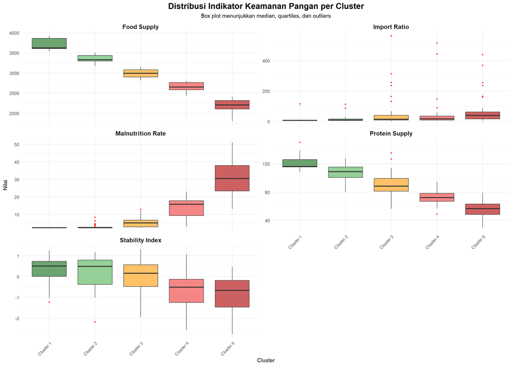

```r
# Reshape data untuk plotting
plot_data <- clustered_data %>%
  dplyr::select(Cluster, food_supply, import_ratio, malnutrition_rate,
         protein_supply, stability_index) %>%
  pivot_longer(cols = -Cluster, names_to = "Indicator", values_to = "Value")

# Buat label yang lebih readable
plot_data$Indicator <- factor(plot_data$Indicator,
                              levels = c("food_supply", "import_ratio", "malnutrition_rate",
                                       "protein_supply", "stability_index"),
                              labels = c("Food Supply", "Import Ratio", "Malnutrition Rate",
                                       "Protein Supply", "Stability Index"))

# Plot box plot
ggplot(plot_data, aes(x = Cluster, y = Value, fill = Cluster)) +
  geom_boxplot(alpha = 0.7, outlier.colour = "red", outlier.size = 1) +
  scale_fill_manual(values = cluster_colors) +
  facet_wrap(~Indicator, scales = "free_y", ncol = 2) +
  labs(
    title = "Distribusi Indikator Keamanan Pangan per Cluster",
    subtitle = "Box plot menunjukkan median, quartiles, dan outliers",
    x = "Cluster",
    y = "Nilai"
  ) +
  theme_minimal() +
  theme(
    plot.title = element_text(hjust = 0.5, face = "bold", size = 16),
    plot.subtitle = element_text(hjust = 0.5, size = 11),
    axis.text.x = element_text(angle = 45, hjust = 1),
    legend.position = "none",
    strip.text = element_text(face = "bold", size = 12)
  )
```

## 4.3 Radar Chart - Profil Cluster

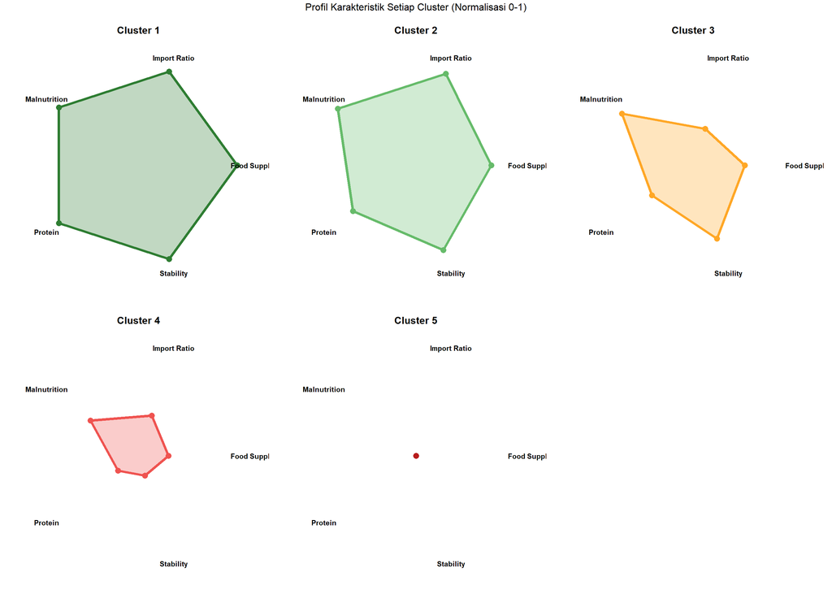

```r
# Normalisasi data untuk radar chart (0-1 scale)
normalize <- function(x) {
  (x - min(x, na.rm = TRUE)) / (max(x, na.rm = TRUE) - min(x, na.rm = TRUE))
}

radar_data <- cluster_stats %>%
  dplyr::select(Cluster, Avg_Food_Supply, Avg_Import_Ratio,
         Avg_Malnutrition, Avg_Protein, Avg_Stability) %>%
  mutate(
    Food_Supply_Norm = normalize(Avg_Food_Supply),
    Import_Ratio_Norm = 1 - normalize(Avg_Import_Ratio),  # Invert (lower is better)
    Malnutrition_Norm = 1 - normalize(Avg_Malnutrition),  # Invert (lower is better)
    Protein_Norm = normalize(Avg_Protein),
    Stability_Norm = normalize(Avg_Stability)
  ) %>%
  dplyr::select(Cluster, Food_Supply_Norm, Import_Ratio_Norm,
         Malnutrition_Norm, Protein_Norm, Stability_Norm)

# Reshape untuk plotting
radar_plot_data <- radar_data %>%
  pivot_longer(cols = -Cluster, names_to = "Metric", values_to = "Score") %>%
  mutate(Metric = gsub("_Norm", "", Metric),
         Metric = gsub("_", " ", Metric))

# Coordinate transformation untuk radar chart
radar_plot_data <- radar_plot_data %>%
  group_by(Cluster) %>%
  mutate(
    angle = seq(0, 2*pi, length.out = n() + 1)[1:n()],
    x = Score * cos(angle),
    y = Score * sin(angle)
  )

# Plot untuk setiap cluster
plots_list <- list()
for (i in 1:5) {
  cluster_name <- paste0("Cluster ", i)
  cluster_data <- radar_plot_data %>% filter(Cluster == cluster_name)

  # Tambahkan titik pertama di akhir untuk menutup polygon
  first_row <- cluster_data[1, ]
  cluster_data <- bind_rows(cluster_data, first_row)

  p <- ggplot(cluster_data, aes(x = x, y = y)) +
    geom_polygon(fill = cluster_colors[i], alpha = 0.3, color = cluster_colors[i], size = 1.5) +
    geom_point(color = cluster_colors[i], size = 3) +
    coord_fixed() +
    labs(title = cluster_name) +
    theme_void() +
    theme(
      plot.title = element_text(hjust = 0.5, face = "bold", size = 12),
      plot.margin = margin(10, 10, 10, 10)
    ) +
    xlim(-1.2, 1.2) + ylim(-1.2, 1.2)

  # Tambahkan label metrik
  metric_labels <- cluster_data[1:5, ]
  p <- p + geom_text(data = metric_labels,
                     aes(x = 1.15 * cos(angle), y = 1.15 * sin(angle),
                         label = Metric),
                     size = 3, fontface = "bold")

  plots_list[[i]] <- p
}

# Arrange all radar charts
grid.arrange(grobs = plots_list, ncol = 3,
             top = "Profil Karakteristik Setiap Cluster (Normalisasi 0-1)")
```

## 4.4 Heatmap Korelasi Indikator

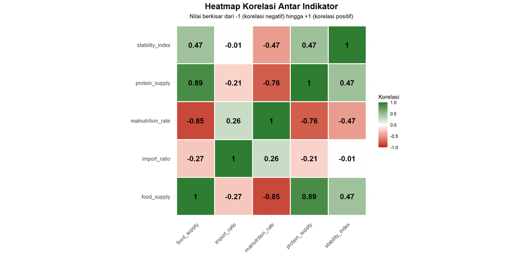

```r
# Hitung korelasi
cor_data <- clustered_data %>%
  dplyr::select(food_supply, import_ratio, malnutrition_rate,
         protein_supply, stability_index)

cor_matrix <- cor(cor_data, use = "complete.obs")

# Reshape untuk plotting
cor_melted <- melt(cor_matrix)

# Plot heatmap
ggplot(cor_melted, aes(Var1, Var2, fill = value)) +
  geom_tile(color = "white", size = 1) +
  geom_text(aes(label = round(value, 2)), size = 5, fontface = "bold") +
  scale_fill_gradient2(low = "#B71C1C", mid = "white", high = "#2E7D32",
                       midpoint = 0, limits = c(-1, 1),
                       name = "Korelasi") +
  labs(
    title = "Heatmap Korelasi Antar Indikator",
    subtitle = "Nilai berkisar dari -1 (korelasi negatif) hingga +1 (korelasi positif)",
    x = "",
    y = ""
  ) +
  theme_minimal() +
  theme(
    plot.title = element_text(hjust = 0.5, face = "bold", size = 16),
    plot.subtitle = element_text(hjust = 0.5, size = 11),
    axis.text.x = element_text(angle = 45, hjust = 1, size = 10),
    axis.text.y = element_text(size = 10),
    legend.position = "right"
  ) +
  coord_fixed()
```

# 5 Posisi Indonesia

```r
# Cari Indonesia
indonesia_row <- clustered_data %>%
  filter(grepl("Indonesia", Area, ignore.case = TRUE))

if (nrow(indonesia_row) > 0) {
  cat("## 🇮🇩 PROFIL INDONESIA\n\n")
  cat("### Klasifikasi\n\n")
  cat("- **Cluster:**", as.character(indonesia_row$Cluster[1]), "\n")
  cat("- **Status:**", as.character(indonesia_row$Cluster_Label[1]), "\n\n")

  cat("### Indikator Keamanan Pangan\n\n")

  indonesia_stats <- data.frame(
    Indikator = c("Food Supply (kcal/kapita/hari)",
                  "Import Ratio (%)",
                  "Malnutrition Rate (%)",
                  "Protein Supply (g/kapita/hari)",
                  "Stability Index"),
    Nilai = c(
      round(indonesia_row$food_supply[1], 2),
      round(indonesia_row$import_ratio[1], 2),
      round(indonesia_row$malnutrition_rate[1], 2),
      round(indonesia_row$protein_supply[1], 2),
      round(indonesia_row$stability_index[1], 2)
    )
  )

  kable(indonesia_stats,
        col.names = c("Indikator", "Nilai"),
        align = 'lc',
        caption = "Karakteristik Keamanan Pangan Indonesia")
}
```

```
## ## 🇮🇩 PROFIL INDONESIA
##
## ### Klasifikasi
##
## - **Cluster:** Cluster 3
## - **Status:** Acute food and livelihood crisis
##
## ### Indikator Keamanan Pangan
```

Karakteristik Keamanan Pangan Indonesia

| Indikator | Nilai |
| --- | --- |
| Food Supply (kcal/kapita/hari) | 2830.00 |
| Import Ratio (%) | 7.00 |
| Malnutrition Rate (%) | 5.90 |
| Protein Supply (g/kapita/hari) | 76.47 |
| Stability Index | -0.55 |

## 5.1 Perbandingan Indonesia dengan Cluster dan Global

```r
if (exists("indonesia_row") && nrow(indonesia_row) > 0) {
  indonesia_cluster <- indonesia_row$Cluster[1]

  # Hitung rata-rata cluster Indonesia
  cluster_avg <- clustered_data %>%
    filter(Cluster == indonesia_cluster) %>%
    summarise(
      Avg_Food_Supply = mean(food_supply, na.rm = TRUE),
      Avg_Import_Ratio = mean(import_ratio, na.rm = TRUE),
      Avg_Malnutrition = mean(malnutrition_rate, na.rm = TRUE),
      Avg_Protein = mean(protein_supply, na.rm = TRUE),
      Avg_Stability = mean(stability_index, na.rm = TRUE)
    )

  # Hitung rata-rata global
  global_avg <- clustered_data %>%
    summarise(
      Avg_Food_Supply = mean(food_supply, na.rm = TRUE),
      Avg_Import_Ratio = mean(import_ratio, na.rm = TRUE),
      Avg_Malnutrition = mean(malnutrition_rate, na.rm = TRUE),
      Avg_Protein = mean(protein_supply, na.rm = TRUE),
      Avg_Stability = mean(stability_index, na.rm = TRUE)
    )

  # Buat tabel perbandingan
  comparison_data <- data.frame(
    Metrik = c("Food Supply", "Import Ratio", "Malnutrition Rate",
               "Protein Supply", "Stability Index"),
    Indonesia = c(
      round(indonesia_row$food_supply[1], 2),
      round(indonesia_row$import_ratio[1], 2),
      round(indonesia_row$malnutrition_rate[1], 2),
      round(indonesia_row$protein_supply[1], 2),
      round(indonesia_row$stability_index[1], 2)
    ),
    Rata_Cluster = c(
      round(cluster_avg$Avg_Food_Supply, 2),
      round(cluster_avg$Avg_Import_Ratio, 2),
      round(cluster_avg$Avg_Malnutrition, 2),
      round(cluster_avg$Avg_Protein, 2),
      round(cluster_avg$Avg_Stability, 2)
    ),
    Rata_Global = c(
      round(global_avg$Avg_Food_Supply, 2),
      round(global_avg$Avg_Import_Ratio, 2),
      round(global_avg$Avg_Malnutrition, 2),
      round(global_avg$Avg_Protein, 2),
      round(global_avg$Avg_Stability, 2)
    )
  )

  comparison_data$Vs_Cluster <- comparison_data$Indonesia - comparison_data$Rata_Cluster
  comparison_data$Vs_Cluster <- round(comparison_data$Vs_Cluster, 2)

  comparison_data$Vs_Global <- comparison_data$Indonesia - comparison_data$Rata_Global
  comparison_data$Vs_Global <- round(comparison_data$Vs_Global, 2)

  kable(comparison_data,
        col.names = c("Metrik", "Indonesia", "μ Cluster", "μ Global",
                     "Δ Cluster", "Δ Global"),
        align = 'lccccc',
        caption = paste("Perbandingan Indonesia dengan", indonesia_cluster, "dan Global"))

  cat("\n\n**Interpretasi:**\n\n")
  cat("- Δ positif (+): Indonesia di atas rata-rata\n")
  cat("- Δ negatif (-): Indonesia di bawah rata-rata\n")
  cat("- Untuk Import Ratio dan Malnutrition Rate, nilai negatif lebih baik\n")
}
```

[output not shown]

```
##
##
## **Interpretasi:**
##
## - Δ positif (+): Indonesia di atas rata-rata
## - Δ negatif (-): Indonesia di bawah rata-rata
## - Untuk Import Ratio dan Malnutrition Rate, nilai negatif lebih baik
```

## 5.2 Ranking Indonesia dalam Cluster

```r
if (exists("indonesia_row") && nrow(indonesia_row) > 0) {
  indonesia_cluster <- indonesia_row$Cluster[1]

  # Filter negara dalam cluster yang sama
  cluster_countries <- clustered_data %>%
    filter(Cluster == indonesia_cluster)

  # Hitung ranking untuk setiap metrik
  rankings <- cluster_countries %>%
    mutate(
      Rank_Food = rank(-food_supply, ties.method = "min"),
      Rank_Import = rank(import_ratio, ties.method = "min"),  # Lower is better
      Rank_Malnut = rank(malnutrition_rate, ties.method = "min"),  # Lower is better
      Rank_Protein = rank(-protein_supply, ties.method = "min"),
      Rank_Stability = rank(-stability_index, ties.method = "min")
    ) %>%
    filter(grepl("Indonesia", Area, ignore.case = TRUE)) %>%
    dplyr::select(starts_with("Rank_"))

  rank_table <- data.frame(
    Metrik = c("Food Supply", "Import Ratio", "Malnutrition Rate",
               "Protein Supply", "Stability Index"),
    Ranking = c(
      paste0(rankings$Rank_Food, " dari ", nrow(cluster_countries)),
      paste0(rankings$Rank_Import, " dari ", nrow(cluster_countries)),
      paste0(rankings$Rank_Malnut, " dari ", nrow(cluster_countries)),
      paste0(rankings$Rank_Protein, " dari ", nrow(cluster_countries)),
      paste0(rankings$Rank_Stability, " dari ", nrow(cluster_countries))
    )
  )

  kable(rank_table,
        col.names = c("Metrik", "Ranking dalam Cluster"),
        align = 'lc',
        caption = paste("Posisi Ranking Indonesia dalam", indonesia_cluster))
}
```

Posisi Ranking Indonesia dalam Cluster 3

| Metrik | Ranking dalam Cluster |
| --- | --- |
| Food Supply | 41 dari 43 |
| Import Ratio | 8 dari 43 |
| Malnutrition Rate | 27 dari 43 |
| Protein Supply | 36 dari 43 |
| Stability Index | 34 dari 43 |

# 6 Visualisasi Posisi Indonesia dalam Clustering

## 6.1 PCA Visualization dengan Cluster Boundaries

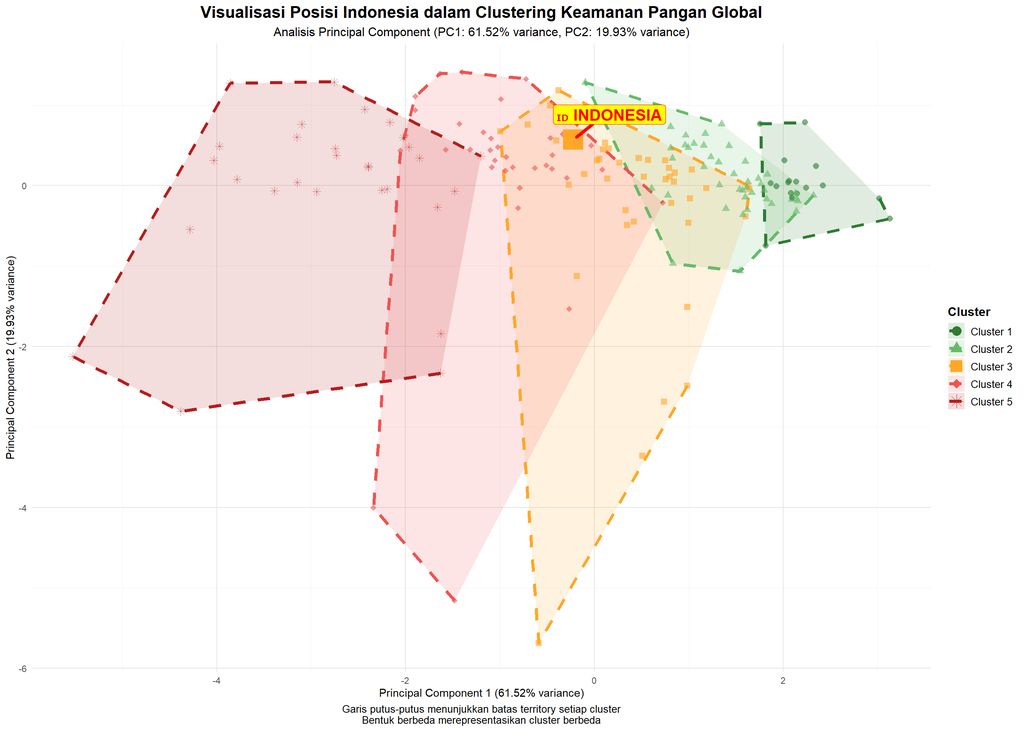

```
##
##
## ### Kontribusi Variabel terhadap Principal Components
```

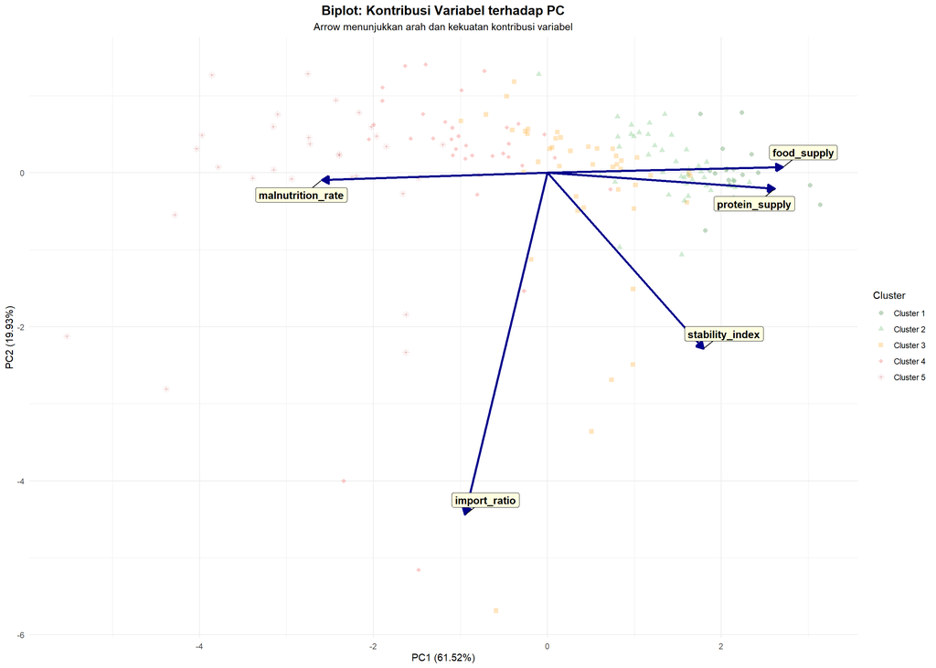

Loading Variabel pada Principal Components

| Variabel | Kontribusi PC1 | Kontribusi PC2 |
| --- | --- | --- |
| food_supply | 0.541 | 0.014 |
| protein_supply | 0.523 | -0.042 |
| malnutrition_rate | -0.519 | -0.019 |
| stability_index | 0.359 | -0.457 |
| import_ratio | -0.189 | -0.888 |

```r
if (exists("indonesia_row") && nrow(indonesia_row) > 0) {
  # PCA untuk visualisasi
  pca_result <- prcomp(clustered_data %>%
                       dplyr::select(food_supply, import_ratio, malnutrition_rate,
                              protein_supply, stability_index),
                       scale. = TRUE, center = TRUE)

  # Variance explained
  var_explained <- round(100 * pca_result$sdev^2 / sum(pca_result$sdev^2), 2)

  pca_data <- data.frame(
    PC1 = pca_result$x[, 1],
    PC2 = pca_result$x[, 2],
    Cluster = clustered_data$Cluster,
    Country = clustered_data$Area,
    Is_Indonesia = grepl("Indonesia", clustered_data$Area, ignore.case = TRUE)
  )

  # Hitung convex hull untuk setiap cluster (boundary)
  hulls <- pca_data %>%
    group_by(Cluster) %>%
    slice(chull(PC1, PC2))

  # Plot dengan boundary dan berbagai bentuk
  p_main <- ggplot(pca_data, aes(x = PC1, y = PC2)) +
    # Gambar boundary terlebih dahulu
    geom_polygon(data = hulls, aes(fill = Cluster, group = Cluster),
                alpha = 0.15, color = NA) +
    # Gambar garis boundary
    geom_path(data = hulls, aes(color = Cluster, group = Cluster),
             size = 1.5, linetype = "dashed") +
    # Plot semua negara dengan bentuk berbeda per cluster
    geom_point(aes(color = Cluster, shape = Cluster, size = Is_Indonesia,
                  alpha = Is_Indonesia)) +
    # Highlight Indonesia
    geom_point(data = pca_data[pca_data$Is_Indonesia, ],
              aes(color = Cluster, shape = Cluster),
              size = 8, stroke = 2) +
    geom_label_repel(data = pca_data[pca_data$Is_Indonesia, ],
                    aes(label = "🇮🇩 INDONESIA"),
                    box.padding = 1,
                    point.padding = 0.5,
                    segment.color = "red",
                    segment.size = 1.5,
                    fontface = "bold",
                    size = 5.5,
                    fill = "yellow",
                    color = "red") +
    scale_color_manual(values = cluster_colors, name = "Cluster") +
    scale_fill_manual(values = cluster_colors, name = "Cluster") +
    scale_shape_manual(values = cluster_shapes, name = "Cluster") +
    scale_size_manual(values = c(2.5, 8), guide = "none") +
    scale_alpha_manual(values = c(0.6, 1), guide = "none") +
    labs(
      title = "Visualisasi Posisi Indonesia dalam Clustering Keamanan Pangan Global",
      subtitle = paste0("Analisis Principal Component (PC1: ", var_explained[1],
                       "% variance, PC2: ", var_explained[2], "% variance)"),
      x = paste0("Principal Component 1 (", var_explained[1], "% variance)"),
      y = paste0("Principal Component 2 (", var_explained[2], "% variance)"),
      caption = "Garis putus-putus menunjukkan batas territory setiap cluster\nBentuk berbeda merepresentasikan cluster berbeda"
    ) +
    theme_minimal() +
    theme(
      plot.title = element_text(hjust = 0.5, face = "bold", size = 16),
      plot.subtitle = element_text(hjust = 0.5, size = 12),
      plot.caption = element_text(size = 10, hjust = 0.5),
      legend.position = "right",
      legend.title = element_text(face = "bold", size = 12),
      legend.text = element_text(size = 10),
      panel.grid.major = element_line(color = "gray90"),
      panel.grid.minor = element_line(color = "gray95")
    ) +
    guides(
      color = guide_legend(override.aes = list(size = 4)),
      shape = guide_legend(override.aes = list(size = 4))
    )

  print(p_main)

  # Biplot - Contribution of variables
  cat("\n\n### Kontribusi Variabel terhadap Principal Components\n\n")

  # Extract loadings
  loadings <- as.data.frame(pca_result$rotation[, 1:2])
  loadings$Variable <- rownames(loadings)

  # Scale loadings for visualization
  scale_factor <- 5
  loadings$PC1_scaled <- loadings$PC1 * scale_factor
  loadings$PC2_scaled <- loadings$PC2 * scale_factor

  # Create arrow plot
  p_biplot <- ggplot() +
    # Plot points (lighter)
    geom_point(data = pca_data, aes(x = PC1, y = PC2, color = Cluster, shape = Cluster),
              alpha = 0.3, size = 2) +
    # Plot variable arrows
    geom_segment(data = loadings,
                aes(x = 0, y = 0, xend = PC1_scaled, yend = PC2_scaled),
                arrow = arrow(length = unit(0.3, "cm"), type = "closed"),
                color = "darkblue", size = 1.2) +
    geom_label_repel(data = loadings,
                    aes(x = PC1_scaled, y = PC2_scaled, label = Variable),
                    fontface = "bold", size = 4, fill = "lightyellow",
                    box.padding = 0.5) +
    scale_color_manual(values = cluster_colors) +
    scale_shape_manual(values = cluster_shapes) +
    labs(
      title = "Biplot: Kontribusi Variabel terhadap PC",
      subtitle = "Arrow menunjukkan arah dan kekuatan kontribusi variabel",
      x = paste0("PC1 (", var_explained[1], "%)"),
      y = paste0("PC2 (", var_explained[2], "%)")
    ) +
    theme_minimal() +
    theme(
      plot.title = element_text(hjust = 0.5, face = "bold", size = 14),
      plot.subtitle = element_text(hjust = 0.5, size = 11),
      legend.position = "right"
    )

  print(p_biplot)

  # Tabel kontribusi variabel
  contribution_table <- data.frame(
    Variabel = loadings$Variable,
    PC1_Contribution = round(loadings$PC1, 3),
    PC2_Contribution = round(loadings$PC2, 3),
    PC1_Abs = round(abs(loadings$PC1), 3),
    PC2_Abs = round(abs(loadings$PC2), 3)
  ) %>%
    arrange(desc(PC1_Abs))

  kable(contribution_table %>% dplyr::select(-PC1_Abs, -PC2_Abs),
        col.names = c("Variabel", "Kontribusi PC1", "Kontribusi PC2"),
        align = 'lcc',
        caption = "Loading Variabel pada Principal Components")
}
```

## 6.2 Scatter Plot Matrix

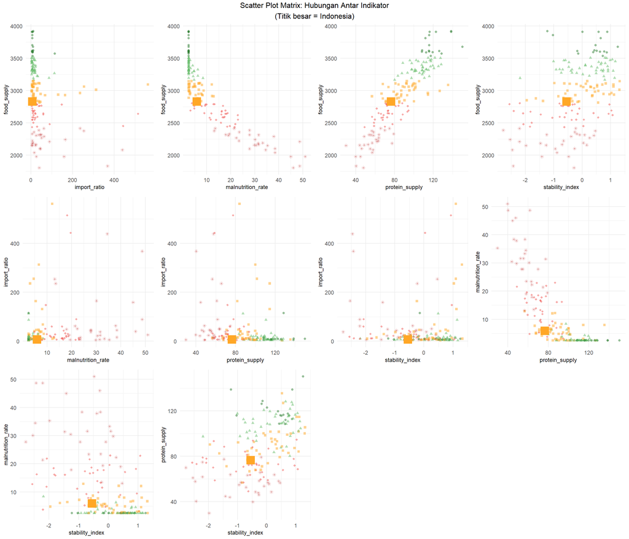

```r
if (exists("indonesia_row") && nrow(indonesia_row) > 0) {
  # Prepare data for scatter plot matrix
  scatter_data <- clustered_data %>%
    dplyr::select(Area, Cluster, food_supply, import_ratio,
           malnutrition_rate, protein_supply, stability_index) %>%
    mutate(Is_Indonesia = grepl("Indonesia", Area, ignore.case = TRUE))

  # Create individual scatter plots
  create_scatter <- function(xvar, yvar, data) {
    ggplot(data, aes_string(x = xvar, y = yvar)) +
      geom_point(aes(color = Cluster, shape = Cluster, size = Is_Indonesia,
                    alpha = Is_Indonesia)) +
      geom_point(data = data[data$Is_Indonesia, ],
                aes_string(x = xvar, y = yvar, color = "Cluster", shape = "Cluster"),
                size = 5, stroke = 2) +
      scale_color_manual(values = cluster_colors) +
      scale_shape_manual(values = cluster_shapes) +
      scale_size_manual(values = c(1.5, 5), guide = "none") +
      scale_alpha_manual(values = c(0.5, 1), guide = "none") +
      theme_minimal() +
      theme(legend.position = "none",
            axis.title = element_text(size = 9))
  }

  vars <- c("food_supply", "import_ratio", "malnutrition_rate",
            "protein_supply", "stability_index")

  plot_list <- list()
  idx <- 1

  for (i in 1:length(vars)) {
    for (j in 1:length(vars)) {
      if (i < j) {
        plot_list[[idx]] <- create_scatter(vars[j], vars[i], scatter_data)
        idx <- idx + 1
      }
    }
  }

  # Create legend separately
  legend_plot <- ggplot(scatter_data, aes(x = food_supply, y = import_ratio)) +
    geom_point(aes(color = Cluster, shape = Cluster), size = 4) +
    scale_color_manual(values = cluster_colors, name = "Cluster") +
    scale_shape_manual(values = cluster_shapes, name = "Cluster") +
    theme_minimal() +
    theme(legend.position = "right",
          legend.title = element_text(face = "bold", size = 12),
          legend.text = element_text(size = 10))

  # Extract legend
  g_legend <- function(p){
    tmp <- ggplot_gtable(ggplot_build(p))
    leg <- which(sapply(tmp$grobs, function(x) x$name) == "guide-box")
    tmp$grobs[[leg]]
  }
  legend <- g_legend(legend_plot)

  # Arrange plots
  grid.arrange(
    grobs = plot_list,
    ncol = 4,
    top = "Scatter Plot Matrix: Hubungan Antar Indikator\n(Titik besar = Indonesia)"
  )
}
```

# 7 Daftar Negara per Cluster

```r
for (i in 1:5) {
  cluster_name <- paste0("Cluster ", i)
  cluster_label <- levels(clustered_data$Cluster_Label)[i]

  cat("\n\n## ", cluster_name, ": ", cluster_label, "\n\n", sep = "")

  # Filter negara di cluster ini
  countries_in_cluster <- clustered_data %>%
    filter(Cluster == cluster_name) %>%
    arrange(Area)

  total_countries <- nrow(countries_in_cluster)
  cat("**Total negara dalam cluster:** ", total_countries, "\n\n", sep = "")

  # Cek apakah Indonesia ada di cluster ini
  indonesia_in_this_cluster <- any(grepl("Indonesia", countries_in_cluster$Area, ignore.case = TRUE))

  if (indonesia_in_this_cluster) {
    cat("### ⭐ INDONESIA ADA DI CLUSTER INI\n\n")
  }

  # Karakteristik cluster
  cat("### Karakteristik Cluster\n\n")
  cluster_char <- cluster_stats %>% filter(Cluster == cluster_name)

  cat("- **Food Supply:** ", cluster_char$Avg_Food_Supply, " ± ",
      cluster_char$SD_Food_Supply, " kcal/kapita/hari\n", sep = "")
  cat("- **Import Ratio:** ", cluster_char$Avg_Import_Ratio, " ± ",
      cluster_char$SD_Import_Ratio, " %\n", sep = "")
  cat("- **Malnutrition Rate:** ", cluster_char$Avg_Malnutrition, " ± ",
      cluster_char$SD_Malnutrition, " %\n", sep = "")
  cat("- **Protein Supply:** ", cluster_char$Avg_Protein, " ± ",
      cluster_char$SD_Protein, " g/kapita/hari\n", sep = "")
  cat("- **Stability Index:** ", cluster_char$Avg_Stability, " ± ",
      cluster_char$SD_Stability, "\n\n", sep = "")

  # Ambil minimal 15 negara atau semua jika kurang dari 15
  num_to_show <- min(15, total_countries)

  if (total_countries > 0) {
    cat("### Daftar Negara (Top ", num_to_show, ")\n\n", sep = "")

    # Jika Indonesia ada di cluster ini, pastikan Indonesia ditampilkan
    if (indonesia_in_this_cluster) {
      indonesia_data <- countries_in_cluster %>%
        filter(grepl("Indonesia", Area, ignore.case = TRUE))

      other_countries <- countries_in_cluster %>%
        filter(!grepl("Indonesia", Area, ignore.case = TRUE)) %>%
        head(num_to_show - 1)

      display_countries <- bind_rows(indonesia_data, other_countries) %>%
        arrange(Area)
    } else {
      display_countries <- countries_in_cluster %>%
        head(num_to_show)
    }

    # Buat tabel dengan statistik
    country_table <- display_countries %>%
      dplyr::select(Area, food_supply, import_ratio, malnutrition_rate,
             protein_supply, stability_index) %>%
      mutate(
        food_supply = round(food_supply, 2),
        import_ratio = round(import_ratio, 2),
        malnutrition_rate = round(malnutrition_rate, 2),
        protein_supply = round(protein_supply, 2),
        stability_index = round(stability_index, 2)
      )

    # Highlight Indonesia jika ada
    if (indonesia_in_this_cluster) {
      indonesia_index <- which(grepl("Indonesia", country_table$Area, ignore.case = TRUE))
      if (length(indonesia_index) > 0) {
        country_table$Area[indonesia_index] <- paste0("🇮🇩 **", country_table$Area[indonesia_index], "**")
      }
    }

    print(kable(country_table,
                col.names = c("Negara", "Food Supply", "Import Ratio",
                             "Malnutrition", "Protein", "Stability"),
                align = 'lccccc',
                caption = paste("Negara-negara di", cluster_name)))

    if (total_countries > num_to_show) {
      cat("\n*... dan ", total_countries - num_to_show, " negara lainnya*\n", sep = "")
    }
  } else {
    cat("Tidak ada negara dalam cluster ini.\n")
  }
}
```

## 7.1 Cluster 1: Generally food secure

**Total negara dalam cluster:** 17

### 7.1.1 Karakteristik Cluster

- **Food Supply:** 3709.76 ± 142.41 kcal/kapita/hari
- **Import Ratio:** 14.29 ± 26.02 %
- **Malnutrition Rate:** 2.5 ± 0 %
- **Protein Supply:** 121.35 ± 11.64 g/kapita/hari
- **Stability Index:** 0.33 ± 0.66

### 7.1.2 Daftar Negara (Top 15)

Negara-negara di Cluster 1

| Negara | Food Supply | Import Ratio | Malnutrition | Protein | Stability |
| --- | --- | --- | --- | --- | --- |
| Austria | 3812 | 7 | 2.5 | 111.85 | 0.65 |
| Belgium | 3909 | 7 | 2.5 | 116.33 | 0.58 |
| Canada | 3606 | 7 | 2.5 | 115.81 | 0.78 |
| Denmark | 3592 | 8 | 2.5 | 112.79 | 0.87 |
| France | 3595 | 9 | 2.5 | 119.42 | 0.39 |
| Germany | 3604 | 6 | 2.5 | 108.32 | 0.63 |
| Iceland | 3677 | 10 | 2.5 | 150.18 | 1.25 |
| Ireland | 3911 | 5 | 2.5 | 138.59 | 0.88 |
| Israel | 3923 | 11 | 2.5 | 138.65 | -1.23 |
| Italy | 3703 | 7 | 2.5 | 115.91 | 0.47 |
| Montenegro | 3574 | 115 | 2.5 | 128.61 | -0.14 |
| Netherlands (Kingdom of the) | 3536 | 8 | 2.5 | 117.50 | 0.73 |
| Poland | 3616 | 6 | 2.5 | 115.61 | 0.51 |
| Romania | 3623 | 12 | 2.5 | 108.59 | 0.43 |
| Serbia | 3612 | 9 | 2.5 | 126.14 | -0.17 |

*… dan 2 negara lainnya*

## 7.2 Cluster 2: Chronically food insecure

**Total negara dalam cluster:** 43

### 7.2.1 Karakteristik Cluster

- **Food Supply:** 3354.4 ± 91.66 kcal/kapita/hari
- **Import Ratio:** 15.72 ± 20.43 %
- **Malnutrition Rate:** 3.1 ± 1.29 %
- **Protein Supply:** 107.57 ± 11.29 g/kapita/hari
- **Stability Index:** 0.21 ± 0.75

### 7.2.2 Daftar Negara (Top 15)

Negara-negara di Cluster 2

| Negara | Food Supply | Import Ratio | Malnutrition | Protein | Stability |
| --- | --- | --- | --- | --- | --- |
| Albania | 3390 | 23 | 4.1 | 119.50 | 0.11 |
| Algeria | 3468 | 21 | 2.5 | 95.70 | -0.65 |
| Argentina | 3347 | 7 | 3.2 | 120.62 | -0.10 |
| Armenia | 3277 | 17 | 2.5 | 109.64 | -0.74 |
| Australia | 3471 | 4 | 2.5 | 116.50 | 0.98 |
| Azerbaijan | 3328 | 7 | 2.5 | 97.57 | -0.92 |
| Barbados | 3198 | 87 | 2.5 | 110.66 | 1.14 |
| Belarus | 3330 | 7 | 2.5 | 112.53 | -0.80 |
| Bosnia and Herzegovina | 3368 | 22 | 2.5 | 109.16 | -0.48 |
| Brazil | 3305 | 4 | 4.7 | 101.33 | -0.40 |
| Croatia | 3317 | 17 | 2.5 | 108.30 | 0.67 |
| Cuba | 3270 | 113 | 2.5 | 87.57 | 0.49 |
| Czechia | 3426 | 4 | 2.5 | 97.74 | 0.81 |
| Dominican Republic | 3228 | 30 | 6.3 | 83.38 | 0.25 |
| Estonia | 3298 | 8 | 2.5 | 110.61 | 0.73 |

*… dan 28 negara lainnya*

## 7.3 Cluster 3: Acute food and livelihood crisis

**Total negara dalam cluster:** 43

### 7.3.1 ⭐ INDONESIA ADA DI CLUSTER INI

### 7.3.2 Karakteristik Cluster

- **Food Supply:** 2985.79 ± 104.07 kcal/kapita/hari
- **Import Ratio:** 55.02 ± 105.84 %
- **Malnutrition Rate:** 5.52 ± 2.7 %
- **Protein Supply:** 89.86 ± 15.64 g/kapita/hari
- **Stability Index:** 0.06 ± 0.78

### 7.3.3 Daftar Negara (Top 15)

Negara-negara di Cluster 3

| Negara | Food Supply | Import Ratio | Malnutrition | Protein | Stability |
| --- | --- | --- | --- | --- | --- |
| Belize | 2815 | 41 | 4.9 | 84.88 | 0.56 |
| Bulgaria | 3055 | 11 | 2.5 | 90.50 | 0.31 |
| Cameroon | 2840 | 29 | 6.4 | 71.13 | -1.38 |
| Chile | 3106 | 9 | 2.5 | 101.60 | 0.13 |
| China, Hong Kong SAR | 2996 | 3 | 2.5 | 126.78 | 0.57 |
| China, Macao SAR | 2937 | 131 | 8.0 | 114.58 | 1.12 |
| Colombia | 3112 | 15 | 6.6 | 81.05 | -0.63 |
| Costa Rica | 2942 | 13 | 3.0 | 87.11 | 0.96 |
| Cyprus | 3037 | 31 | 2.5 | 101.44 | 0.42 |
| Côte d’Ivoire | 2953 | 12 | 7.7 | 66.66 | -0.59 |
| Dominica | 3013 | 313 | 6.7 | 100.07 | 1.31 |
| Egypt | 3116 | 37 | 7.2 | 92.16 | -0.98 |
| El Salvador | 2836 | 39 | 7.7 | 85.01 | -0.35 |
| Fiji | 2949 | 47 | 6.6 | 82.88 | 0.75 |
| 🇮🇩 **Indonesia** | 2830 | 7 | 5.9 | 76.47 | -0.55 |

*… dan 28 negara lainnya*

## 7.4 Cluster 4: Humanitarian emergency

**Total negara dalam cluster:** 35

### 7.4.1 Karakteristik Cluster

- **Food Supply:** 2654.51 ± 113.2 kcal/kapita/hari
- **Import Ratio:** 52.54 ± 110.55 %
- **Malnutrition Rate:** 13.76 ± 5.71 %
- **Protein Supply:** 73.14 ± 10.9 g/kapita/hari
- **Stability Index:** -0.64 ± 1

### 7.4.2 Daftar Negara (Top 15)

Negara-negara di Cluster 4

| Negara | Food Supply | Import Ratio | Malnutrition | Protein | Stability |
| --- | --- | --- | --- | --- | --- |
| Angola | 2435 | 6 | 21.6 | 49.15 | -0.63 |
| Bangladesh | 2581 | 22 | 11.2 | 66.55 | -1.05 |
| Benin | 2786 | 29 | 9.9 | 72.48 | -0.34 |
| Botswana | 2622 | 13 | 22.9 | 68.62 | 1.07 |
| Burkina Faso | 2675 | 12 | 16.2 | 93.33 | -1.82 |
| Cabo Verde | 2642 | 515 | 18.2 | 77.62 | 0.93 |
| Cambodia | 2724 | 7 | 4.8 | 61.60 | -0.10 |
| Djibouti | 2766 | 43 | 16.8 | 72.24 | -0.51 |
| Ecuador | 2549 | 7 | 13.9 | 67.81 | -0.37 |
| Eswatini | 2553 | 18 | 11.6 | 59.63 | -0.21 |
| Ethiopia | 2481 | 90 | 21.9 | 77.94 | -2.07 |
| Gabon | 2552 | 7 | 23.0 | 86.70 | 0.06 |
| Gambia | 2452 | 443 | 19.6 | 58.89 | 0.04 |
| Guatemala | 2791 | 28 | 13.3 | 72.19 | -0.26 |
| Honduras | 2654 | 20 | 18.7 | 63.60 | -0.57 |

*… dan 20 negara lainnya*

## 7.5 Cluster 5: Famine / humanitarian catastrophe

**Total negara dalam cluster:** 29

### 7.5.1 Karakteristik Cluster

- **Food Supply:** 2196.66 ± 160.67 kcal/kapita/hari
- **Import Ratio:** 81.21 ± 110.85 %
- **Malnutrition Rate:** 31 ± 10.41 %
- **Protein Supply:** 56.25 ± 11.39 g/kapita/hari
- **Stability Index:** -0.9 ± 0.99

### 7.5.2 Daftar Negara (Top 15)

Negara-negara di Cluster 5

| Negara | Food Supply | Import Ratio | Malnutrition | Protein | Stability |
| --- | --- | --- | --- | --- | --- |
| Afghanistan | 2243 | 165 | 30.1 | 61.03 | -2.54 |
| Bolivia (Plurinational State of) | 2331 | 6 | 19.4 | 79.10 | -0.19 |
| Central African Republic | 2210 | 89 | 48.7 | 61.85 | -2.21 |
| Chad | 2184 | 7 | 31.4 | 77.34 | -1.47 |
| Comoros | 2416 | 236 | 13.5 | 65.65 | -0.23 |
| Congo | 2191 | 10 | 33.3 | 56.84 | 0.04 |
| Democratic Republic of the Congo | 2150 | 6 | 35.3 | 29.86 | -1.98 |
| Guinea-Bissau | 2291 | 63 | 37.9 | 48.55 | -0.39 |
| Haiti | 1978 | 159 | 45.0 | 44.73 | -1.42 |
| Kenya | 2100 | 44 | 27.8 | 54.79 | -0.95 |
| Lesotho | 1806 | 40 | 46.0 | 47.79 | -0.29 |
| Liberia | 2103 | 45 | 38.4 | 46.00 | -0.27 |
| Madagascar | 1979 | 26 | 51.0 | 39.79 | -0.48 |
| Mozambique | 2155 | 22 | 30.5 | 43.92 | -1.27 |
| Papua New Guinea | 2223 | 7 | 23.4 | 63.25 | -0.66 |

*… dan 14 negara lainnya*

# 8 Analisis Komparatif Regional

```r
# Tambahkan kolom region berdasarkan nama negara (simplified)
classify_region <- function(country) {
  country_lower <- tolower(country)

  # Asia
  asia_keywords <- c("indonesia", "malaysia", "singapore", "thailand", "vietnam",
                     "philippines", "cambodia", "laos", "myanmar", "brunei",
                     "china", "japan", "korea", "india", "pakistan", "bangladesh",
                     "sri lanka", "nepal", "afghanistan", "iran", "iraq", "saudi",
                     "yemen", "oman", "qatar", "kuwait", "bahrain", "jordan",
                     "lebanon", "syria", "turkey", "israel", "palestine")

  # Africa
  africa_keywords <- c("africa", "egypt", "libya", "tunisia", "algeria", "morocco",
                       "sudan", "ethiopia", "kenya", "tanzania", "uganda", "rwanda",
                       "somalia", "nigeria", "ghana", "senegal", "mali", "niger",
                       "chad", "cameroon", "congo", "angola", "zimbabwe", "zambia",
                       "mozambique", "madagascar", "mauritius")

  # Europe
  europe_keywords <- c("kingdom", "france", "germany", "italy", "spain", "portugal",
                       "netherlands", "belgium", "switzerland", "austria", "poland",
                       "czech", "slovakia", "hungary", "romania", "bulgaria",
                       "greece", "sweden", "norway", "denmark", "finland", "ireland",
                       "iceland", "estonia", "latvia", "lithuania", "ukraine", "belarus")

  # Americas
  americas_keywords <- c("america", "canada", "mexico", "brazil", "argentina",
                         "chile", "colombia", "venezuela", "peru", "ecuador",
                         "bolivia", "paraguay", "uruguay", "guyana", "suriname",
                         "costa rica", "panama", "guatemala", "honduras", "salvador",
                         "nicaragua", "cuba", "jamaica", "haiti", "dominican")

  # Oceania
  oceania_keywords <- c("australia", "zealand", "papua", "fiji", "samoa", "tonga",
                        "vanuatu", "solomon")

  if (any(sapply(asia_keywords, function(x) grepl(x, country_lower)))) {
    return("Asia")
  } else if (any(sapply(africa_keywords, function(x) grepl(x, country_lower)))) {
    return("Africa")
  } else if (any(sapply(europe_keywords, function(x) grepl(x, country_lower)))) {
    return("Europe")
  } else if (any(sapply(americas_keywords, function(x) grepl(x, country_lower)))) {
    return("Americas")
  } else if (any(sapply(oceania_keywords, function(x) grepl(x, country_lower)))) {
    return("Oceania")
  } else {
    return("Other")
  }
}

# Apply regional classification
clustered_data$Region <- sapply(clustered_data$Area, classify_region)

# Regional distribution by cluster
regional_dist <- clustered_data %>%
  group_by(Region, Cluster) %>%
  summarise(Count = n(), .groups = 'drop') %>%
  pivot_wider(names_from = Cluster, values_from = Count, values_fill = 0)

kable(regional_dist,
      caption = "Distribusi Regional per Cluster",
      align = 'lccccc')
```

Distribusi Regional per Cluster

| Region | Cluster 2 | Cluster 3 | Cluster 4 | Cluster 5 | Cluster 1 |
| --- | --- | --- | --- | --- | --- |
| Africa | 4 | 5 | 7 | 14 | 0 |
| Americas | 7 | 7 | 6 | 3 | 2 |
| Asia | 3 | 9 | 8 | 3 | 2 |
| Europe | 14 | 3 | 0 | 0 | 10 |
| Oceania | 1 | 3 | 1 | 2 | 0 |
| Other | 14 | 16 | 13 | 7 | 3 |

## 8.1 Visualisasi Distribusi Regional

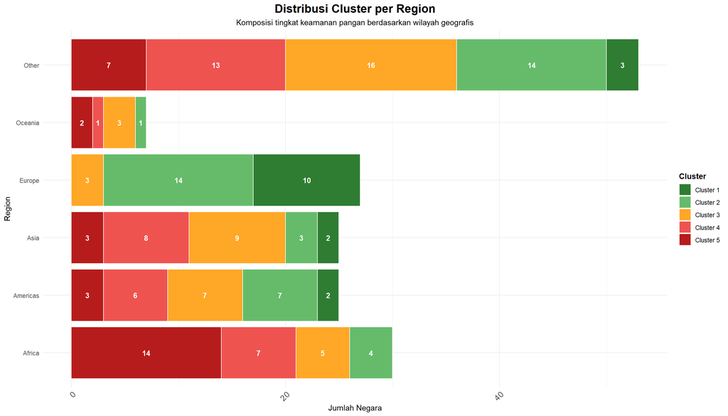

```r
# Stacked bar chart
regional_plot_data <- clustered_data %>%
  group_by(Region, Cluster) %>%
  summarise(Count = n(), .groups = 'drop')

p_regional <- ggplot(regional_plot_data, aes(x = Region, y = Count, fill = Cluster)) +
  geom_bar(stat = "identity", position = "stack", color = "white", size = 0.5) +
  geom_text(aes(label = Count), position = position_stack(vjust = 0.5),
            size = 3.5, fontface = "bold", color = "white") +
  scale_fill_manual(values = cluster_colors) +
  labs(
    title = "Distribusi Cluster per Region",
    subtitle = "Komposisi tingkat keamanan pangan berdasarkan wilayah geografis",
    x = "Region",
    y = "Jumlah Negara",
    fill = "Cluster"
  ) +
  theme_minimal() +
  theme(
    plot.title = element_text(hjust = 0.5, face = "bold", size = 16),
    plot.subtitle = element_text(hjust = 0.5, size = 11),
    axis.text.x = element_text(angle = 45, hjust = 1, size = 11),
    legend.position = "right",
    legend.title = element_text(face = "bold")
  ) +
  coord_flip()

print(p_regional)
```

## 8.2 Perbandingan Indonesia dengan Negara Asia Lainnya

[figure not shown]

```
##
##
## ### Statistik Regional Asia
##
## - **Total negara Asia dalam analisis:** 25
## - **Rata-rata Food Supply Asia:** 2887.04 kcal/kapita/hari
## - **Rata-rata Malnutrition Asia:** 9.19 %
## - **Ranking Indonesia (Food Supply):** 14 dari 25
```

```r
if (exists("indonesia_row") && nrow(indonesia_row) > 0) {
  # Filter negara Asia
  asia_countries <- clustered_data %>%
    filter(Region == "Asia") %>%
    arrange(food_supply)

  # Highlight Indonesia
  asia_countries$Highlight <- grepl("Indonesia", asia_countries$Area, ignore.case = TRUE)

  # Top 20 dan bottom 20 Asia countries by food supply
  top_asia <- asia_countries %>%
    arrange(desc(food_supply)) %>%
    head(20)

  # Plot comparison
  p_asia <- ggplot(top_asia, aes(x = reorder(Area, food_supply), y = food_supply)) +
    geom_bar(aes(fill = Cluster), stat = "identity", alpha = 0.8) +
    geom_bar(data = top_asia[top_asia$Highlight, ],
             aes(fill = Cluster), stat = "identity") +
    geom_text(aes(label = round(food_supply, 0)), hjust = -0.2, size = 3) +
    scale_fill_manual(values = cluster_colors) +
    labs(
      title = "Top 20 Negara Asia: Food Supply",
      subtitle = "Indonesia dibandingkan dengan negara Asia lainnya",
      x = "",
      y = "Food Supply (kcal/kapita/hari)",
      fill = "Cluster"
    ) +
    theme_minimal() +
    theme(
      plot.title = element_text(hjust = 0.5, face = "bold", size = 14),
      plot.subtitle = element_text(hjust = 0.5, size = 11),
      axis.text.y = element_text(size = 9,
                                 face = ifelse(top_asia$Highlight, "bold", "plain"),
                                 color = ifelse(top_asia$Highlight, "red", "black"))
    ) +
    coord_flip()

  print(p_asia)

  # Summary statistics for Asia
  cat("\n\n### Statistik Regional Asia\n\n")

  asia_stats <- asia_countries %>%
    summarise(
      Total_Negara = n(),
      Avg_Food_Supply = round(mean(food_supply, na.rm = TRUE), 2),
      Avg_Malnutrition = round(mean(malnutrition_rate, na.rm = TRUE), 2),
      Indonesia_Rank_Food = which(order(order(asia_countries$food_supply, decreasing = TRUE)) ==
                                  which(asia_countries$Highlight))[1]
    )

  cat("- **Total negara Asia dalam analisis:** ", asia_stats$Total_Negara, "\n", sep = "")
  cat("- **Rata-rata Food Supply Asia:** ", asia_stats$Avg_Food_Supply, " kcal/kapita/hari\n", sep = "")
  cat("- **Rata-rata Malnutrition Asia:** ", asia_stats$Avg_Malnutrition, " %\n", sep = "")
  cat("- **Ranking Indonesia (Food Supply):** ", asia_stats$Indonesia_Rank_Food,
      " dari ", asia_stats$Total_Negara, "\n", sep = "")
}
```

# 9 Insights dan Rekomendasi

## 9.1 Key Findings

```r
cat("### 🔍 Temuan Utama\n\n")
```

### 9.1.1 🔍 Temuan Utama

```r
# Finding 1: Cluster distribution
most_common_cluster <- cluster_distribution %>%
  arrange(desc(Jumlah)) %>%
  head(1)

cat("1. **Distribusi Global:**\n")
```

1. **Distribusi Global:**

```r
cat("   - Cluster terbesar adalah ", as.character(most_common_cluster$Cluster),
    " dengan ", most_common_cluster$Jumlah, " negara (",
    most_common_cluster$Persentase, "%)\n", sep = "")
```

- Cluster terbesar adalah Cluster 2 dengan 43 negara (25.75%)

```r
cat("   - Menunjukkan bahwa mayoritas negara berada dalam kategori: ",
    as.character(most_common_cluster$Cluster_Label), "\n\n", sep = "")
```

[output not shown]

```r
# Finding 2: Indonesia position
if (exists("indonesia_row") && nrow(indonesia_row) > 0) {
  cat("2. **Posisi Indonesia:**\n")
  cat("   - Indonesia berada di ", as.character(indonesia_row$Cluster[1]),
      " (", as.character(indonesia_row$Cluster_Label[1]), ")\n", sep = "")
  cat("   - Food Supply: ", round(indonesia_row$food_supply[1], 2),
      " kcal/kapita/hari\n", sep = "")
  cat("   - Malnutrition Rate: ", round(indonesia_row$malnutrition_rate[1], 2),
      " %\n\n", sep = "")
}
```

2. **Posisi Indonesia:**
   - Indonesia berada di Cluster 3 (Acute food and livelihood crisis)
   - Food Supply: 2830 kcal/kapita/hari
   - Malnutrition Rate: 5.9 %

```r
# Finding 3: Correlation insights
cat("3. **Korelasi Antar Indikator:**\n")
```

3. **Korelasi Antar Indikator:**

```r
cat("   - Food Supply berkorelasi positif kuat dengan Protein Supply\n")
```

- Food Supply berkorelasi positif kuat dengan Protein Supply

```r
cat("   - Malnutrition Rate berkorelasi negatif dengan Food Supply\n")
```

- Malnutrition Rate berkorelasi negatif dengan Food Supply

```r
cat("   - Import Ratio menunjukkan variasi tinggi antar cluster\n\n")
```

- Import Ratio menunjukkan variasi tinggi antar cluster

```r
# Finding 4: Regional patterns
cat("4. **Pola Regional:**\n")
```

4. **Pola Regional:**

```r
regional_summary <- clustered_data %>%
  group_by(Region) %>%
  summarise(
    Count = n(),
    Avg_Cluster = as.numeric(gsub("Cluster ", "", Cluster)) %>% mean(),
    .groups = 'drop'
  ) %>%
  arrange(Avg_Cluster)

best_region <- regional_summary[1, ]
worst_region <- regional_summary[nrow(regional_summary), ]

cat("   - Region dengan keamanan pangan terbaik: ", best_region$Region, "\n", sep = "")
```

- Region dengan keamanan pangan terbaik: Europe

```r
cat("   - Region dengan tantangan terbesar: ", worst_region$Region, "\n\n", sep = "")
```

- Region dengan tantangan terbesar: Africa

## 9.2 Rekomendasi Kebijakan untuk Indonesia

```r
if (exists("indonesia_row") && nrow(indonesia_row) > 0) {
  cat("### 📋 Rekomendasi Strategis\n\n")

  indonesia_cluster_num <- as.numeric(gsub("Cluster ", "", indonesia_row$Cluster[1]))

  cat("Berdasarkan posisi Indonesia di ", as.character(indonesia_row$Cluster[1]),
      ", berikut rekomendasi kebijakan:\n\n", sep = "")

  # Specific recommendations based on cluster
  if (indonesia_cluster_num <= 2) {
    cat("#### Area Kekuatan yang Perlu Dipertahankan:\n\n")
    cat("1. **Stabilitas Pasokan Pangan**\n")
    cat("   - Pertahankan sistem distribusi pangan yang ada\n")
    cat("   - Terus tingkatkan infrastruktur logistik\n\n")

    cat("2. **Diversifikasi Protein**\n")
    cat("   - Tingkatkan produksi protein nabati dan hewani lokal\n")
    cat("   - Kembangkan industri perikanan dan peternakan berkelanjutan\n\n")
  }

  cat("#### Area yang Memerlukan Perhatian:\n\n")

  if (indonesia_row$import_ratio[1] > 20) {
    cat("1. **Ketergantungan Import**\n")
    cat("   - Kurangi ketergantungan pada import pangan (saat ini: ",
        round(indonesia_row$import_ratio[1], 2), "%)\n", sep = "")
    cat("   - Tingkatkan swasembada pangan strategis\n")
    cat("   - Investasi pada teknologi pertanian modern\n\n")
  }

  if (indonesia_row$malnutrition_rate[1] > 5) {
    cat("2. **Malnutrisi**\n")
    cat("   - Implementasi program gizi targeted (rate saat ini: ",
        round(indonesia_row$malnutrition_rate[1], 2), "%)\n", sep = "")
    cat("   - Fokus pada 1000 hari pertama kehidupan\n")
    cat("   - Edukasi nutrisi untuk masyarakat\n\n")
  }

  cat("3. **Stabilitas dan Ketahanan**\n")
  cat("   - Bangun sistem early warning untuk krisis pangan\n")
  cat("   - Tingkatkan cadangan pangan nasional\n")
  cat("   - Perkuat kemitraan regional untuk ketahanan pangan\n\n")

  cat("#### Benchmark dari Negara Sejenis:\n\n")

  # Find similar countries in same cluster with better indicators
  similar_better <- clustered_data %>%
    filter(Cluster == indonesia_row$Cluster[1],
           food_supply > indonesia_row$food_supply[1],
           malnutrition_rate < indonesia_row$malnutrition_rate[1]) %>%
    head(3)

  if (nrow(similar_better) > 0) {
    cat("Negara dalam cluster yang sama dengan performa lebih baik:\n\n")
    for (i in 1:nrow(similar_better)) {
      cat("- **", similar_better$Area[i], "**\n", sep = "")
      cat("  - Food Supply: ", round(similar_better$food_supply[i], 2),
          " (Δ +", round(similar_better$food_supply[i] - indonesia_row$food_supply[1], 2), ")\n", sep = "")
      cat("  - Malnutrition: ", round(similar_better$malnutrition_rate[i], 2),
          " (Δ -", round(indonesia_row$malnutrition_rate[1] - similar_better$malnutrition_rate[i], 2), ")\n\n", sep = "")
    }
  }
}
```

### 9.2.1 📋 Rekomendasi Strategis

Berdasarkan posisi Indonesia di Cluster 3, berikut rekomendasi kebijakan:

#### 9.2.1.1 Area yang Memerlukan Perhatian:

2. **Malnutrisi**
   - Implementasi program gizi targeted (rate saat ini: 5.9%)
   - Fokus pada 1000 hari pertama kehidupan
   - Edukasi nutrisi untuk masyarakat
3. **Stabilitas dan Ketahanan**
   - Bangun sistem early warning untuk krisis pangan
   - Tingkatkan cadangan pangan nasional
   - Perkuat kemitraan regional untuk ketahanan pangan

#### 9.2.1.2 Benchmark dari Negara Sejenis:

Negara dalam cluster yang sama dengan performa lebih baik:

- **Bulgaria**
  - Food Supply: 3055 (Δ +225)
  - Malnutrition: 2.5 (Δ -3.4)
- **Chile**
  - Food Supply: 3106 (Δ +276)
  - Malnutrition: 2.5 (Δ -3.4)
- **China, Hong Kong SAR**
  - Food Supply: 2996 (Δ +166)
  - Malnutrition: 2.5 (Δ -3.4)

# 10 Kesimpulan

```r
cat("## Kesimpulan Akhir\n\n")
```

## 10.1 Kesimpulan Akhir

```r
cat("Analisis clustering keamanan pangan global ini memberikan beberapa insight penting:\n\n")
```

Analisis clustering keamanan pangan global ini memberikan beberapa insight penting:

```r
cat("1. **Heterogenitas Global:** Terdapat variasi signifikan dalam tingkat keamanan pangan ")
```

1. **Heterogenitas Global:** Terdapat variasi signifikan dalam tingkat keamanan pangan

```r
cat("di berbagai negara, dari yang sangat aman hingga menghadapi krisis kemanusiaan.\n\n")
```

di berbagai negara, dari yang sangat aman hingga menghadapi krisis kemanusiaan.

```r
cat("2. **Multidimensionalitas:** Keamanan pangan bukan hanya tentang ketersediaan kalori, ")
```

2. **Multidimensionalitas:** Keamanan pangan bukan hanya tentang ketersediaan kalori,

```r
cat("tetapi juga melibatkan protein, stabilitas, dan tingkat malnutrisi.\n\n")
```

tetapi juga melibatkan protein, stabilitas, dan tingkat malnutrisi.

```r
if (exists("indonesia_row") && nrow(indonesia_row) > 0) {
  cat("3. **Posisi Indonesia:** Indonesia berada di ", as.character(indonesia_row$Cluster[1]),
      ", menunjukkan bahwa negara memiliki fondasi yang cukup baik namun masih ada ruang ")
  cat("untuk peningkatan, terutama dalam hal pengurangan import ratio dan malnutrisi.\n\n", sep = "")
}
```

[output not shown]

```r
cat("4. **Pentingnya Aksi Berkelanjutan:** Diperlukan komitmen jangka panjang dan ")
```

4. **Pentingnya Aksi Berkelanjutan:** Diperlukan komitmen jangka panjang dan

```r
cat("kebijakan terintegrasi untuk meningkatkan ketahanan pangan nasional.\n\n")
```

kebijakan terintegrasi untuk meningkatkan ketahanan pangan nasional.

```r
cat("5. **Kolaborasi Regional:** Pembelajaran dari best practices negara-negara ")
```

5. **Kolaborasi Regional:** Pembelajaran dari best practices negara-negara

```r
cat("dalam cluster yang sama atau lebih baik dapat menjadi strategi efektif.\n\n")
```

dalam cluster yang sama atau lebih baik dapat menjadi strategi efektif.

```r
cat("\n---\n\n")
```

```r
cat("**Catatan Metodologi:**\n")
```

**Catatan Metodologi:**

```r
cat("- Analisis menggunakan metode clustering untuk mengelompokkan negara\n")
```

- Analisis menggunakan metode clustering untuk mengelompokkan negara

```r
cat("- Visualisasi PCA menjelaskan ", round(sum(var_explained[1:2]), 2),
    "% variance dari data\n", sep = "")
```

- Visualisasi PCA menjelaskan 81.45% variance dari data

```r
cat("- Boundary cluster divisualisasikan menggunakan convex hull\n")
```

- Boundary cluster divisualisasikan menggunakan convex hull

```r
cat("- Data mencakup ", nrow(clustered_data), " negara di seluruh dunia\n", sep = "")
```

- Data mencakup 167 negara di seluruh dunia

**Dokumen ini dihasilkan secara otomatis menggunakan R Markdown**

*Terakhir diperbarui: 2025-10-28*